# Statystyka II PG - Wykład

Michał Maj

2021-02-07

# 1 Wstęp

## 1.1 Machine Learning i Statystyka

**Uczeie maszynowe / Machine Learning (ML)** jest zbiorem metod/algorytmów, służących do automatycznego wykrywania wzorców w danych oraz do wykorzystywania odkrytych wzorców do przewidywania przyszłości (predykcji) lub podejmowania innych decyzji w warunkach niepewności. ML jest subdziedziną **Sztucznej Inteligencji / Artificial Intelligence (AI)** i bazuje na metodach znanych ze **Statystyki**.

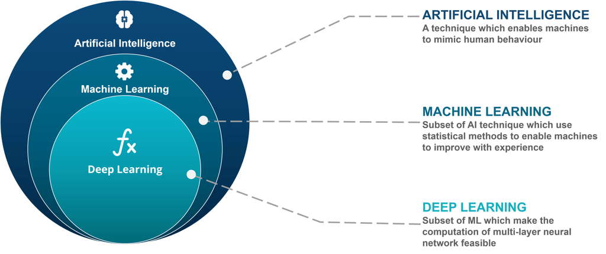

Na temat różnić między Statystyką, a Machine Learningiem możnaby dywagować w nieskończoność (niepotrzebnie), jednakże najlepiej i najprościej ujął to profesor Robert Tibshirani, współautor [An Introduction to Statistical Learning: With Applications in R](https://www.ime.unicamp.br/~dias/Intoduction%20to%20Statistical%20Learning.pdf):

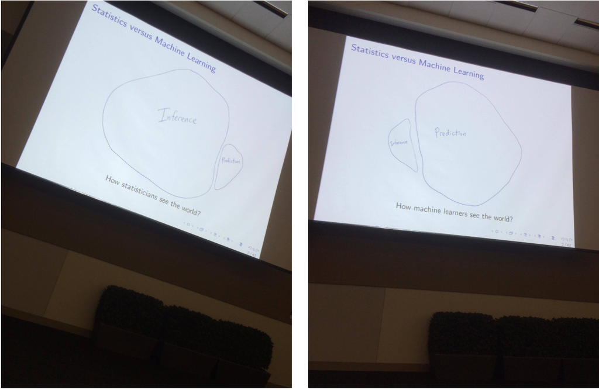

## 1.2 Typy/zadania Uczenia Maszynowego

Uczenie maszynowe z reguły dzielone jest na 3 podstawowe podkategorie:

### 1.2.1 Uczenie nadzorowane (supervised learning)

W ramach uczenia nadzorowanego naszym zadaniem jest znalezienie pewnego **“optymalnego mapowania”** ze **zmiennych objaśniających** $X$ do **zmiennych objaśnianych** $Y$ mając do dyspozyjcji **zbiór treningowy** $\mathcal{D}=\left\{\left(\mathbf{x}_{i}, y_{i}\right)\right\}_{i=1}^{N}$, zawierający realizację owych zmiennych, gdzie $N$ oznacza liczbę obserwacji z wbiorze treningowym. W najprostszym przypadku $\mathbf{x}_{i}$ jest $D$-wymiarowym wektorem numerycznym $\mathbf{x}_{i} \in \mathbb{R}^D$, choć w rzeczywistości może on posiadać bardziej złożoną strukturę, może on np. reprezentować obraz, dźwięk, tekst, szereg czasowy itp. Podobnie postać $y_{i}$ może być dowolna, jednakże w większości przypadków zakładac będziemy, że $y_{i}$ zmienną kategoryczną i przyjmuje wartości z pewnego skończonego zbioru $y_{i} \in \{1, ..., C\}$ lub jest skalarem $y_{i} \in \mathbb{R}$

Gdy $y_{i}$ jest zmienną kategoryczną mówimy, że mamy do czynienia z **klasyfikacjią** (lub **rozpoznawaniem wzorców**), jeśli $y_{i}$ jest skalarem mówimy, że mamy do czynienia z **regresją**.

Z probabilistycznego punktu widzenia zainteresowani jesteśmy rozkładem warunkowym $p(y_{i} | \mathbf{x}_{i}, \mathbf{\theta})$, gdzie $\mathbf{\theta}$ jest wektorem parametrów modelu.

Przykłady:

1. Predykcja cen mieszkań. Na podstawie zestawu zmiennych numerycznych i kategorycznych zawierających informacje o mieszkaniu chcielibyśmy przewidzieć jego cenę.

```
##      crim zn indus chas   nox    rm  age    dis rad tax ptratio      b lstat
## 1 0.00632 18  2.31    0 0.538 6.575 65.2 4.0900   1 296    15.3 396.90  4.98
## 2 0.02731  0  7.07    0 0.469 6.421 78.9 4.9671   2 242    17.8 396.90  9.14
## 3 0.02729  0  7.07    0 0.469 7.185 61.1 4.9671   2 242    17.8 392.83  4.03
## 4 0.03237  0  2.18    0 0.458 6.998 45.8 6.0622   3 222    18.7 394.63  2.94
## 5 0.06905  0  2.18    0 0.458 7.147 54.2 6.0622   3 222    18.7 396.90  5.33
## 6 0.02985  0  2.18    0 0.458 6.430 58.7 6.0622   3 222    18.7 394.12  5.21
##   medv
## 1 24.0
## 2 21.6
## 3 34.7
## 4 33.4
## 5 36.2
## 6 28.7
```

2. Diagnostyka raka piersi. Na podstawie zestawu zmiennych numerycznych i kategorycznych zawierających informacje o pacjencie chielibyśmy dowiedzieć się czy typ raka jest łagodny czy złośliwy.

```
##        Id Cl.thickness Cell.size Cell.shape Marg.adhesion Epith.c.size
## 1 1000025            5         1          1             1            2
## 2 1002945            5         4          4             5            7
## 3 1015425            3         1          1             1            2
## 4 1016277            6         8          8             1            3
## 5 1017023            4         1          1             3            2
## 6 1017122            8        10         10             8            7
##   Bare.nuclei Bl.cromatin Normal.nucleoli Mitoses     Class
## 1           1           3               1       1    benign
## 2          10           3               2       1    benign
## 3           2           3               1       1    benign
## 4           4           3               7       1    benign
## 5           1           3               1       1    benign
## 6          10           9               7       1 malignant
```

3. Detekcja SPAM. Na podstawie zawartości e-maili chcielibyśmy zaklasyfikować wiadomość jako SPAM bądź prawidłową korespondencję.

```
##   make address  all num3d  our over remove internet order mail receive will
## 1 0.00    0.64 0.64     0 0.32 0.00   0.00     0.00  0.00 0.00    0.00 0.64
## 2 0.21    0.28 0.50     0 0.14 0.28   0.21     0.07  0.00 0.94    0.21 0.79
## 3 0.06    0.00 0.71     0 1.23 0.19   0.19     0.12  0.64 0.25    0.38 0.45
## 4 0.00    0.00 0.00     0 0.63 0.00   0.31     0.63  0.31 0.63    0.31 0.31
## 5 0.00    0.00 0.00     0 0.63 0.00   0.31     0.63  0.31 0.63    0.31 0.31
## 6 0.00    0.00 0.00     0 1.85 0.00   0.00     1.85  0.00 0.00    0.00 0.00
##   people report addresses free business email  you credit your font num000
## 1   0.00   0.00      0.00 0.32     0.00  1.29 1.93   0.00 0.96    0   0.00
## 2   0.65   0.21      0.14 0.14     0.07  0.28 3.47   0.00 1.59    0   0.43
## 3   0.12   0.00      1.75 0.06     0.06  1.03 1.36   0.32 0.51    0   1.16
## 4   0.31   0.00      0.00 0.31     0.00  0.00 3.18   0.00 0.31    0   0.00
## 5   0.31   0.00      0.00 0.31     0.00  0.00 3.18   0.00 0.31    0   0.00
## 6   0.00   0.00      0.00 0.00     0.00  0.00 0.00   0.00 0.00    0   0.00
##   money hp hpl george num650 lab labs telnet num857 data num415 num85
```

[output cut: 27 more lines]

4. Detekcja obiektów. Na podstawie obrazów chcielibyśmy zakwalifikować obiekty znajdujące się na nich, a także wskazać ich konkretne położenie. Jest to połączenie klasyfikacji i regresji.

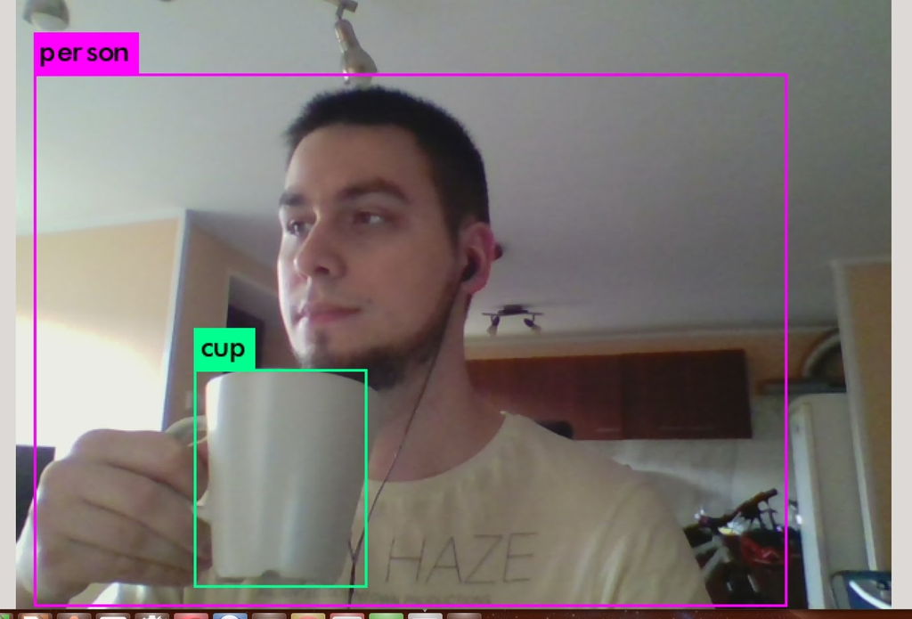

5. Segmentacja obrazu. Na podstawie obrazów chcielibyśmy zaklasyfikowac każdy pixel znajdujący się na nich.

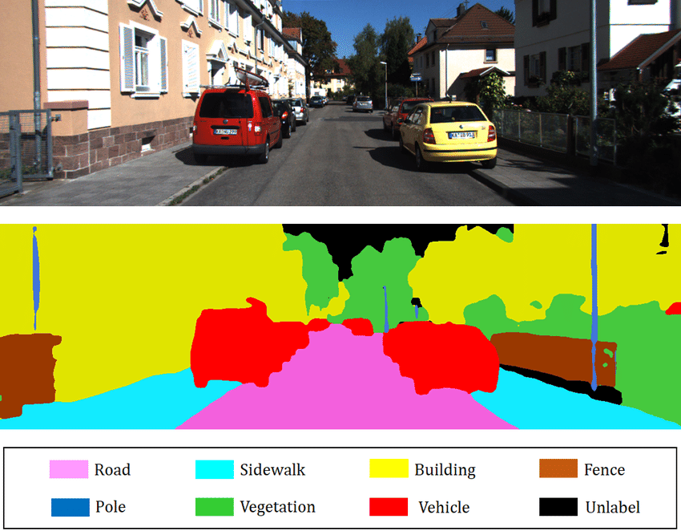

### 1.2.2 Uczenie nienadzorowane (unsupervised learning)

W przeciwieństwie do uczenia nadzorowanego, w uczeniu nienzdzorowanym dysponujemy tylko inputem $\mathcal{D}=\left\{\mathbf{x}_{i}\right\}_{i=1}^{N}$, a naszym celem jest odnalezienie “interesujących wzorców”. Zadania tego typu są zazwyczaj trudniejsze do poprawnego zdefiniowania, ponieważ nie od razu wiemy czym są “interesujące wzorce” oraz jak poprawnie określić metrykę błędu (w przeciwieństwie do uczenia nadzorowanego, gdzie mamy mozliwość porównania prawdziwej odpowiedzi $y_{i}$ z predykcją $\hat{y}_{i}$).

W przypadku uczenia z nadzorem zainteresowani byliśmy rozkładem warunkowym $p(y_{i} | \mathbf{x}_{i}, \mathbf{\theta})$, w uczeniu nienadzorowanym budować będziemy modele w oparciu o rozkład $p(\mathbf{x}_{i} | \mathbf{\theta})$.

### 1.2.3 Uczenie ze wzmocnieniem (reinforcement learning)

W przypadku uczenia ze wzmocnieniem nie dysponujemy zbiorem treningowym w żadnej postaci. Zamiast tego inteligentny agent uczy się jakie akcje powinien podejmować w danym środowisku, aby zmaksymalizować nagrodę. Proces uczenia odbywa się (często w czasie rzeczywistym) poprzez podejmowanie przez agenta kolejnych prób w wyniku czego zostaje on nagrodzony bądź ukarany.